# 326.212 Final Project: Part 2

## 2014-10451 Baek Dae Hyun

## Part 2

### Q1

```r
var_remove<-c("Station.code","Address","Latitude","Longitude","Item.code",   "Unit.of.measurement","Good.Blue.","Normal.Green.","Bad.Yellow.","Very.bad.Red.")
index<-sapply(var_remove, function (x) return (which(x==names(data))))

data<-data[,-index]
names(data)
```

```
## [1] "Measurement.date"       "Average.value"          "Instrument.status"
## [4] "Item.name"              "Station.name.district." "Pollution level"
```

제거할 열 이름을 저장한 하나의 긴 벡터를 정의하고, sapply 함수를 통해 각 열의 index를 찾았다. 그리고 그 index에 해당하는 열을 뺀 데이터 프레임을 다시 data에 저장하였다.

### Q2

```r
type<-sapply(names(data), function (x) return (typeof(data[,x])))

var_factor<-names(data)[which(type=="character")]
for (i in 1:length(var_factor)){
    data[,var_factor[i]]<-factor(data[,var_factor[i]])
}
str(data)
```

```
## 'data.frame':    3885066 obs. of  6 variables:
##  $ Measurement.date      : Factor w/ 25906 levels "2017-01-01 00:00",..: 1 1 1 1 1 1 1 1 1 1 ...
##  $ Average.value         : num  0.004 0.059 1.2 0.002 73 57 0.006 0.068 1.3 0.002 ...
##  $ Instrument.status     : int  0 0 0 0 0 0 0 0 0 0 ...
##  $ Item.name             : Factor w/ 6 levels "CO","NO2","O3",..: 6 2 1 3 4 5 6 2 1 3 ...
##  $ Station.name.district.: Factor w/ 25 levels "Dobong-gu","Dongdaemun-gu",..: 13 13 13 13 13 13 14 14 14 14 ...
##  $ Pollution level       : Factor w/ 4 levels "Bad(Yellow)",..: 2 3 2 2 3 1 2 1 2 2 ...
```

1번 문제와 유사한 방법으로 sapply 함수를 이용해 각 변수(열)의 typeof() 실행 결과를 계산할 수 있다. 그 결과를 type에 저장하고, 변수(열) 중 type 내에서의 값이 character인 것을 찾아 var_factor에 저장하였다. 그리고 for문을 이용해 var_factor에 해당하는 변수(열)을 모두 factorize하였다. 결과는 str()로 확인 가능하다.

### Q3-1

```r
#NA check
sum(is.na(data))
```

```
## [1] 26160
```

```r
sapply(names(data),function(x){
  sum(is.na(data[,x]))
})
```

```
##       Measurement.date          Average.value      Instrument.status
##                      0                      0                      0
##              Item.name Station.name.district.        Pollution level
##                      0                      0                  26160
```

data에 missing value가 26160개나 있음을 발견하였다. 이 26160개의 missing value가 어디에서 발생한 것인지를 확인하기 위해 sapply를 통해 data의 모든 열에 대하여 각 열의 na value 값을 갖는 것의 개수의 합을 출력하였다. 그 결과, Pollution level에서 missing value가 전부 들어가 있음을 알 수 있다.

### Q3-2

```r
data%>%
  filter(Average.value<0)%>%
  dplyr::select(Average.value,Instrument.status)%>%
  count(Average.value,Instrument.status)
```

```
##   Average.value Instrument.status     n
## 1            -1                 1   761
## 2            -1                 2   376
## 3            -1                 4 19186
## 4            -1                 8  3156
## 5            -1                 9   361
```

Pollution level은 Part 1에서 정의된 변수로, 정의된 바에 의하면 그것이 NA인 이유는 Average value<0이거나 Very bad(Red)보다 클 때이다. Average value가 음수인 case=23840, Average value가 Very bad(Red)보다 큰 case=26160-23840=2320임을 코드 구현 없이 자연스럽게 알 수 있다. Average value가 음수인 경우 그 값은 항상 -1이었으며, 그 때의 Instrument status 값은 항상 0이 아니었다. 따라서 Average value가 음수인 경우 항상 Instrument의 상태가 정상이 아닌 경우에 해당하고 보여지며 이 때 -1의 값은 기계가 실제로 오염물질을 측정한 수치가 아니라 기계의 오류를 표시하는 indicator와 유사한 느낌으로 생각된다. 따라서 이 경우 Average value에 평균 값 대체를 고려하거나 아예 -1의 값을 갖는 모든 항을 제거하는 complete case analysis를 생각해볼 수도 있겠다. 한편 Average value가 해당 item의 Very bad(Red) 수치보다 큰 경우는 앞서 논의한 경우처럼 일관성 있는 수치를 가지지 않고 큰 변동을 나타내며 하나하나가 실측된 데이터로서 의미있는 수치로 여겨진다. 따라서 이 경우는 기계가 인식하는 최대 오염물질의 양보다 실제 양이 더 커서 발생한 오류로서, 이 때에 Average value 값은 바꾸지 않되 Pollution level은 가장 심각한 레벨인 Very bad(Red)로 대체하는 것이 타당해보인다.

### Q3-3

```r
#split data into data0(Average value<=Very.bad.Red.), data1(Average value>Very.bad.Red.)
#For all data1 rows, change Pollution level = "Very bad(Red)"

data0<-data%>%
  left_join(item)%>%
  filter(Average.value<=Very.bad.Red.)
data1<-data%>%
  left_join(item)%>%
  filter(Average.value>Very.bad.Red.)%>%
  mutate(`Pollution level`="Very bad(Red)")

#rbind data0, data1 and select certain columns that question requires.
m<-rbind(data0,data1)%>%
  filter(Average.value>=0)%>%
  dplyr::select("Measurement.date","Average.value","Instrument.status","Item.name","Station.name.district.",`Pollution level`)

data<-m #substitute orginal data we used to new, NA processed data.
head(data)
```

```
##   Measurement.date Average.value Instrument.status Item.name
## 1 2017-01-01 00:00         0.004                 0       SO2
## 2 2017-01-01 00:00         0.059                 0       NO2
## 3 2017-01-01 00:00         1.200                 0        CO
## 4 2017-01-01 00:00         0.002                 0        O3
## 5 2017-01-01 00:00        73.000                 0      PM10
## 6 2017-01-01 00:00        57.000                 0     PM2.5
##   Station.name.district. Pollution level
## 1              Jongno-gu      Good(Blue)
## 2              Jongno-gu   Normal(Green)
## 3              Jongno-gu      Good(Blue)
## 4              Jongno-gu      Good(Blue)
## 5              Jongno-gu   Normal(Green)
## 6              Jongno-gu     Bad(Yellow)
```

앞선 문제의 논리에 근거하여 결측치를 처리해보자. 우선 Average value의 값이 그 item의 Very bad(Red) 값보다 큰 경우, Pollution level만 Very bad(Red)로 수정한다. 여기서 사용하는 data는 앞선 문제 조건에 의해 Very bad(Red) 열이 삭제되었으므로 part1에서 import한 item 데이터(Very bad(Red) 열을 갖고 있는 데이터)를 left_join한 뒤 작업하였다. 그 다음으로 Average value 값이 음수인 행을 처리해보자. 앞서 논의한 바와 같이 이 경우 기계의 오류가 발생한 경우이므로 평균 값 대체나 아예 행을 삭제하는 방안을 고려해야 한다. 평균 값을 대체한다고 하였을 때는 지역, 계절, 연도에 따른 추세와 변동성을 모두 고려하여야 할 것이고 특히 이 데이터가 시계열 데이터임을 감안하면 평균(또는 중앙값 등) 대체는 상당히 통계적으로 justify하기 어려울 것으로 보인다. 따라서 본 연구에서는 과감하게 -1의 값을 갖는 행을 모두 제거, 총 23840개의 행을 앞으로의 연구 대상에서 제외한다.

### Q4-1

```r
#frequency table
table(data$Instrument.status)
```

```
##
##       0       1       2       4       8       9
## 3775778   28956    3612    3566   29185   20129
```

```r
#proportion table
table(data$Instrument.status)/nrow(data)
```

```
##
##            0            1            2            4            8            9
## 0.9778702412 0.0074991725 0.0009354542 0.0009235409 0.0075584801 0.0052131111
```

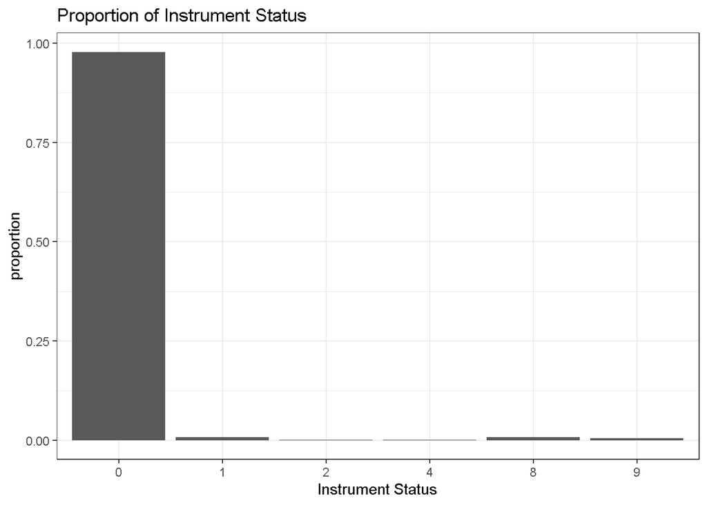

```r
#proportion plot
ggplot(data,aes(x=factor(Instrument.status)))+
  geom_bar(aes(y = (..count..)/sum(..count..)))+
  labs(x="Instrument Status",y="proportion",title="Proportion of Instrument Status") +
  theme_bw()
```

table()을 이용하여 Instrument status의 도수와 빈도를 나타내는 table을 만들 수 있으며, 추가적으로 ggplot + geom_bar을 이용해 각 범주의 비율을 그림으로 나타낼 수 있다.

### Q4-2

```r
data%>%
  left_join(item)%>%
  filter(Instrument.status==9)%>%
  dplyr::select(Average.value,Very.bad.Red.)%>%
  head()#not that much abnormal data of Average value
```

```
##   Average.value Very.bad.Red.
## 1           1.5            50
## 2          62.0           500
## 3           2.3            50
## 4           2.0            50
## 5          52.0           500
## 6          69.0           500
```

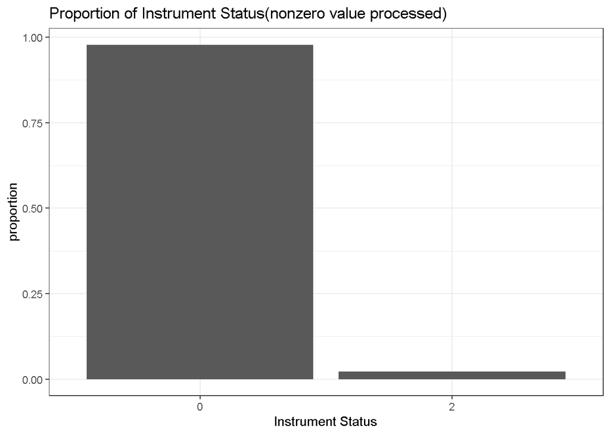

```r
data<-data%>%
  mutate(Instrument.status=ifelse(Instrument.status!=0,2,Instrument.status))
#consider all Instrument status with nonzero value(just as definition, means not normal) as abnormal(Instrument status=2)

ggplot(data,aes(x=factor(Instrument.status)))+
  geom_bar(aes(y = (..count..)/sum(..count..)))+
  labs(x="Instrument Status",y="proportion",title="Proportion of Instrument Status(nonzero value processed)") +
  theme_bw()
```

```r
data_part2q4<-data
```

앞선 문제의 그림을 보면 0의 값을 갖는 경우가 95% 이상이고 나머지 범주들은 모두 합쳐봤자 5% 채 되지 않는다. 앞서 언급한 내용처럼 Instrument가 0이 아닌 것은 기계 상의 문제가 있는 경우라고 볼 수 있고 이들을 하나의 범주로 합치는 것이 괜찮은 방법으로 보인다. 한편 Instrument status 값이 0이 아니더라도, 앞서 결측치 처리 논의에서처럼 Average value 값이 -1과 같은 터무니 없는 숫자는 아니므로 측정된 Average.value 값 자체는 의미가 있다고 보여진다(다만 그것의 신뢰성이 떨어진다는 의미로 해석할 수 있을 것이다). 따라서 4: Power cut off, 8: Under repair과 같이 기계의 치명적 오류를 나타내는 범주로 합치는 것은 좋지 않다고 생각된다. 또한 9: abnormal data로 합치기에는 코드 결과를 보면 Average.value가 Very.Bad(Red)보다 매우 큰 형태의 이상치라고 볼 수는 없기 때문에 이 또한 적당하지 않다. 한편 2: Abnormal로 합친다면 의미상으로 0을 제외한 모든 다른 범주를 넓은 범위에서 포함할 수 있으므로 2로 0을 제외한 범주들을 다 합치는게 타당해보인다.

### Q5

```r
data%>%
  group_by(Item.name)%>%
  filter(Average.value==max(Average.value))%>%
  dplyr::select(Measurement.date,Station.name.district.,Average.value)
```

```
## # A tibble: 6 x 4
## # Groups:   Item.name [6]
##   Item.name Measurement.date Station.name.district. Average.value
##   <chr>     <fct>            <fct>                          <dbl>
## 1 CO        2017-01-15 20:00 Dobong-gu                      71.7
## 2 PM10      2018-01-02 09:00 Gangseo-gu                   3586
## 3 O3        2018-03-05 10:00 Guro-gu                        33.6
## 4 SO2       2018-03-06 09:00 Guro-gu                         3.74
## 5 NO2       2018-03-06 09:00 Guro-gu                        38.4
## 6 PM2.5     2018-04-02 16:00 Yongsan-gu                   6256
```

data를 Item.name 별로 group_by()하고 각각 Average value가 최댓값을 갖는 행을 filter하여 그것의 날짜/시각과 지역을 출력하도록 하였고 코드 실행 결과에 문제의 답이 잘 정리되어있다.

### Q6

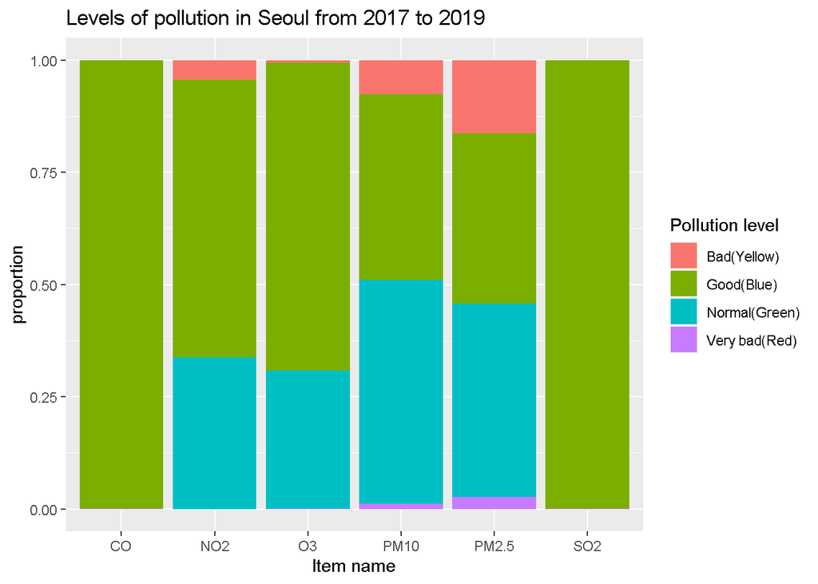

```r
data%>%
  ggplot()+
  geom_bar(aes(x=Item.name, fill=`Pollution level`),position = "fill")+
  labs(title="Levels of pollution in Seoul from 2017 to 2019", x="Item name",y="proportion")+
  theme(plot.title = element_text(hjust = 0))
```

x=Item.name, fill=`Pollution level`, position=“fill”로 하여 총 높이 1에 각 Pollution level 범주가 어느 비율로 있는지 색깔로 구분하여 나타나는 bar chart를 그릴 수 있다. title은 대개 default로 왼쪽정렬되어 나타나지만, user의 R setting에 따라 title이 plot의 중앙에 나오게 설정하는 경우도 있음을 고려하여 확실하게 그림과 똑같이 묘사하기 위해 강제로 왼쪽 정렬되게끔 옵션을 추가하였다(theme(plot.title = element_text(hjust = 0)).

### Q7

```r
head(data)
```

```
##   Measurement.date Average.value Instrument.status Item.name
## 1 2017-01-01 00:00         0.004                 0       SO2
## 2 2017-01-01 00:00         0.059                 0       NO2
## 3 2017-01-01 00:00         1.200                 0        CO
## 4 2017-01-01 00:00         0.002                 0        O3
## 5 2017-01-01 00:00        73.000                 0      PM10
## 6 2017-01-01 00:00        57.000                 0     PM2.5
##   Station.name.district. Pollution level
## 1              Jongno-gu      Good(Blue)
## 2              Jongno-gu   Normal(Green)
## 3              Jongno-gu      Good(Blue)
## 4              Jongno-gu      Good(Blue)
## 5              Jongno-gu   Normal(Green)
## 6              Jongno-gu     Bad(Yellow)
```

### Q8

```r
data%>%
  filter(Item.name=="PM2.5")%>%
  group_by(Station.name.district.)%>%
  summarise(
    PM2.5avg=mean(Average.value)
  )%>%
  filter(rank(PM2.5avg)%in%c(1,25))
```

```
## # A tibble: 2 x 2
##   Station.name.district. PM2.5avg
##   <fct>                     <dbl>
## 1 Gangbuk-gu                 21.7
## 2 Yeongdeungpo-gu            31.4
```

답 : 가장 높은구-영등포구, 가장 낮은구 - 강북구

### Q9

```r
PM2.5<-data%>%
  filter(Item.name=="PM2.5",Station.name.district.%in%c("Gangbuk-gu","Yeongdeungpo-gu"))%>%
  dplyr::select(Average.value,Station.name.district.)

var.test(PM2.5$Average.value~PM2.5$Station.name.district.)
```

```
##
##  F test to compare two variances
##
## data:  PM2.5$Average.value by PM2.5$Station.name.district.
## F = 0.074143, num df = 25878, denom df = 25887, p-value < 2.2e-16
## alternative hypothesis: true ratio of variances is not equal to 1
## 95 percent confidence interval:
##  0.07235833 0.07597183
## sample estimates:
## ratio of variances
##         0.07414307
```

```r
#p-value<0.05, we say they have non-equal variance

t.test(PM2.5$Average.value~PM2.5$Station.name.district.,alternative="less",
       var.equal=FALSE,alpha=0.05)
```

```
##
##  Welch Two Sample t-test
##
## data:  PM2.5$Average.value by PM2.5$Station.name.district.
## t = -21.826, df = 29706, p-value < 2.2e-16
## alternative hypothesis: true difference in means is less than 0
## 95 percent confidence interval:
##       -Inf -8.961086
## sample estimates:
##      mean in group Gangbuk-gu mean in group Yeongdeungpo-gu
##                      21.73751                      31.42900
```

```r
#p-value<0.05, we say population means are different.
```

2개의 서로 다른 집단의 모평균이 다른지 검정하기에 앞서 variance가 같은지 test 한다. p-value<0.05로 두 집단의 variance가 같다고 할 수 없으므로, 단측 t 검정에서 var.equal=FALSE 옵션을 넣고 진행한다. 단측 t 검정의 p-value<0.05이므로 귀무가설을 기각, 영등포구와 강북구의 초미세면지 평균 배출량의 차이가 유의하다고 할 수 있다.

### Q10

```r
ymdh<-data.frame(sapply(c("year","month","mday","hour"),function (x){
  get(x)(parse_datetime(as.character(data$Measurement.date)))
}))

data<-cbind(data,ymdh)%>%
  dplyr::rename(Year=year,Month=month,Day=mday,Hour=hour)
head(data)
```

```
##   Measurement.date Average.value Instrument.status Item.name
## 1 2017-01-01 00:00         0.004                 0       SO2
## 2 2017-01-01 00:00         0.059                 0       NO2
## 3 2017-01-01 00:00         1.200                 0        CO
## 4 2017-01-01 00:00         0.002                 0        O3
## 5 2017-01-01 00:00        73.000                 0      PM10
## 6 2017-01-01 00:00        57.000                 0     PM2.5
##   Station.name.district. Pollution level Year Month Day Hour
## 1              Jongno-gu      Good(Blue) 2017     1   1    0
## 2              Jongno-gu   Normal(Green) 2017     1   1    0
## 3              Jongno-gu      Good(Blue) 2017     1   1    0
## 4              Jongno-gu      Good(Blue) 2017     1   1    0
## 5              Jongno-gu   Normal(Green) 2017     1   1    0
## 6              Jongno-gu     Bad(Yellow) 2017     1   1    0
```

parse_datetime()을 통해 Measurement date를 parsing하고, sapply 함수를 통해 year(), month(), day(), hour()을 모든 date에 대해 자동으로 적용, 계산된 값을 dataframe으로 저장하고 이것을 기존에 작업하던 dataframe과 합쳤다.

### Q11

[figure not shown]

```r
data%>%
  dplyr::select(Average.value,Item.name,Month)%>%
  filter(Item.name%in%c("PM2.5","PM10"))%>%
  group_by(Month)%>%
  summarise(
    avg25=mean(Average.value[which(Item.name=="PM2.5")]),
    avg10=mean(Average.value[which(Item.name=="PM10")])
  )%>%
  ggplot(aes(x=Month))+
  geom_line(aes(y=avg25),colour="green")+
  geom_line(aes(y=avg10),colour="blue")+
  labs(x="Month",y="Average value",title="Average value of PM2.5(blue), PM10(green)")+
  scale_x_continuous(breaks=seq(1,12,by=1))+
  theme_bw()
```

### Q12-1

```r
#dataframe(spread)
data.spread<-data%>%
  dplyr::select(Measurement.date,Station.name.district.,Item.name,Average.value)%>%
  tidyr::spread(key="Item.name",value="Average.value")%>%
  dplyr::select(CO:SO2)
head(data.spread)
```

```
##    CO   NO2    O3 PM10 PM2.5   SO2
## 1 0.9 0.051 0.002   81    40 0.006
## 2 1.1 0.052 0.002   76    50 0.006
## 3 1.2 0.062 0.002   63    49 0.006
## 4 0.6 0.045 0.003   73    46 0.005
## 5 1.2 0.046 0.001   63    51 0.004
## 6 0.9 0.042 0.002   68    53 0.004
```

같은 날짜(시각), 같은 지역에서 측정한 6개의 서로 다른 오염물질의 양을 하나의 데이터로 정리하기 위하여 Measurement.date,Station.name.district.와 Item.name,Average.value를 select하고 key=item.name, value=average.value로 하여 data를 spread한 뒤 CO:S02까지의 열만 select하여 데이터프레임에 저장하였다.

### Q12-1 (결측치 제거)

```r
#remove na rows
data.spread<-data.spread%>%
    filter(!is.na(CO),!is.na(SO2),!is.na(PM2.5),!is.na(PM10),!is.na(NO2),!is.na(O3))

head(data.spread)
```

```
##    CO   NO2    O3 PM10 PM2.5   SO2
## 1 0.9 0.051 0.002   81    40 0.006
## 2 1.1 0.052 0.002   76    50 0.006
## 3 1.2 0.062 0.002   63    49 0.006
## 4 0.6 0.045 0.003   73    46 0.005
## 5 1.2 0.046 0.001   63    51 0.004
## 6 0.9 0.042 0.002   68    53 0.004
```

```r
sum(is.na(data.spread))
```

```
## [1] 0
```

na가 하나라도 있는 행을 모두 제거하기 위하여 filter(!is.na())를 모든 열에 대해 공통 적용하였다.

### Q12-2

```r
cor(data.spread)
```

```
##                CO        NO2           O3        PM10        PM2.5        SO2
## CO     1.00000000 0.07979967 -0.066164261 0.146536320  0.182353623 0.24672406
## NO2    0.07979967 1.00000000  0.592673864 0.033433791  0.038580415 0.73405217
## O3    -0.06616426 0.59267386  1.000000000 0.003790692 -0.001106375 0.73953749
## PM10   0.14653632 0.03343379  0.003790692 1.000000000  0.227061371 0.04475998
## PM2.5  0.18235362 0.03858042 -0.001106375 0.227061371  1.000000000 0.05251920
## SO2    0.24672406 0.73405217  0.739537494 0.044759981  0.052519203 1.00000000
```

cor() 함수로 상관관계행렬을 구하였다.

### Q12-3

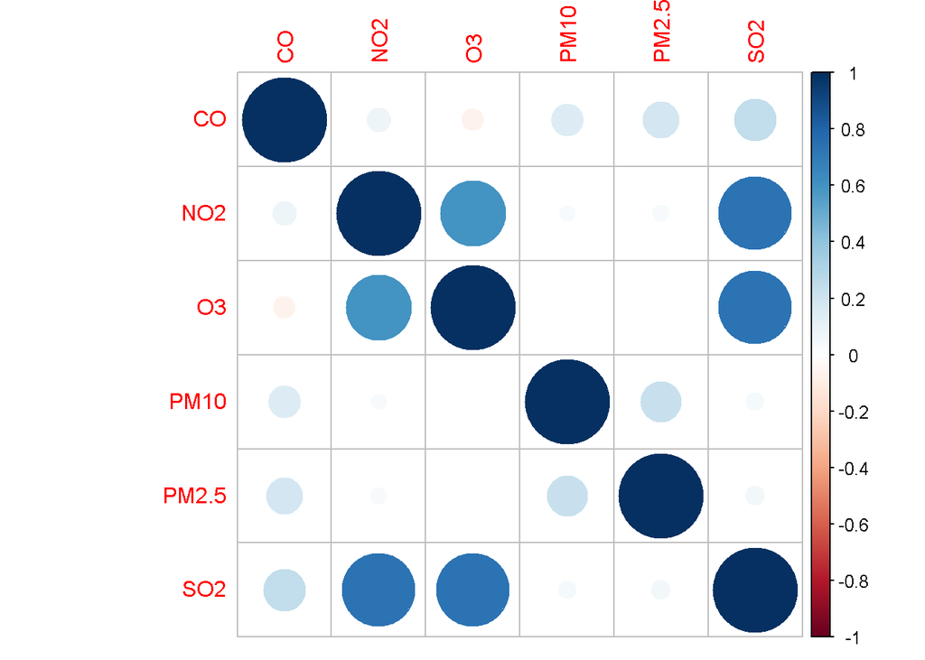

```r
corrplot::corrplot(cor(data.spread))
```

대각 성분을 제외하고 나머지 원의 크기와 색깔의 진하기를 통해 두 변수간 상관관계의 정도를 가늠할 수 있다. NO2와 SO2, NO2와 O3, SO2와 O3 간의 상관관계가 높고, 그 외의 변수 조합은 상관관계가 적게 나타난다.

### Q12-4

[figure not shown]

```r
p_1<-data%>%
  filter(Item.name %in% c("NO2","O3"))%>%
  group_by(Month)%>%
  summarise(
    avgN02=mean(Average.value[which(Item.name=="NO2")]),
    avgO3=mean(Average.value[which(Item.name=="O3")])
  )%>%
  ggplot(aes(x=Month))+
  geom_line(aes(y=avgN02),colour="green")+
  geom_line(aes(y=avgO3),colour="blue")+
  labs(x="Month",y="Average value",title="Monthly Average value of NO2(blue), O3(green)",collapse="")+
  scale_x_continuous(breaks=seq(1,12,by=1))+
  theme_bw()

p_2<-data%>%
  filter(Item.name %in% c("NO2","O3"))%>%
  group_by(Hour)%>%
  summarise(
    avgN02=mean(Average.value[which(Item.name=="NO2")]),
    avgO3=mean(Average.value[which(Item.name=="O3")])
  )%>%
  ggplot(aes(x=Hour))+
  geom_line(aes(y=avgN02),colour="green")+
  geom_line(aes(y=avgO3),colour="blue")+
  labs(x="Hour",y="Average value",title="Hourly Average value of NO2(blue), O3(green)")+
  scale_x_continuous(breaks=seq(0,23,by=1))+
  theme_bw()
print(p_1)
```

[figure not shown]

```r
print(p_2)
```

Q11과 동일한 코드를 이용하면 NO2와 O3에 대해서 월별, 시간별 NO2 와 O3의 변화를 나타내는 꺾은선 그래프를 그릴 수 있다. 월별과 시간별 그래프를 살펴보면 둘다 NO2가 상승하는 구간에서 O3는 하강하고, NO2가 하강하는 구간에서 O3는 상승하는 형태로서 서로 개형이 거의 정반대임을 알 수 있다.특히 월별 그래프에서는 O3가 최댓값일 때 NO2는 거의 최소이고, 거꾸로 O3가 최소일 때 NO2는 최댓값을 보여 더 극단적인 그래프 추이를 보였다. 앞서 corrplot에서 볼 수 있듯이 NO2와 O3의 상관관계는 작지 않은 크기로 나타났으나(0.59), 월별 그리고 시간별 변화 추이는 서로 거의 정반대이다.